# Biostat 203B Homework 2 Solutions

Due Feb 7 @ 11:59PM

Supasara Prasertphong

Use tidyverse (ggpot2, dplyr) to explore the [MIMIC-III](https://mimic.physionet.org) data introduced in [homework 1](https://ucla-biostat203b-2020winter.github.io/hw/hw1/hw1.html).

## Q1

Demographic information of the patients admitted into hospital is available in `ADMISSION.csv`. See https://mimic.physionet.org/mimictables/admissions/ for details of each field in this file. Summarize following variables using appropriate graphs:

- admission year
- admission month
- admission week day
- admission hour
- length of hospital stay
- admission type
- number of admissions per patient
- admission location
- insurance
- language
- religion
- martial status
- ethnicity
- death

Note it is possible that one patient (uniquely identified by the `SUBJECT_ID`) is admitted into hospital multiple times. When summarizing some demographic information, it makes sense to summarize based on only unique patients.

**Solution**

```r
library(tidyverse)
library(lubridate)
library(dplyr)
```

#Import Data

```r
admissions <- read_csv("/home/203bdata/mimic-iii/ADMISSIONS.csv")
admissions
```

```
## # A tibble: 58,976 x 19
##    ROW_ID SUBJECT_ID HADM_ID ADMITTIME           DISCHTIME
##     <dbl>      <dbl>   <dbl> <dttm>              <dttm>
##  1     21         22  165315 2196-04-09 12:26:00 2196-04-10 15:54:00
##  2     22         23  152223 2153-09-03 07:15:00 2153-09-08 19:10:00
##  3     23         23  124321 2157-10-18 19:34:00 2157-10-25 14:00:00
##  4     24         24  161859 2139-06-06 16:14:00 2139-06-09 12:48:00
##  5     25         25  129635 2160-11-02 02:06:00 2160-11-05 14:55:00
##  6     26         26  197661 2126-05-06 15:16:00 2126-05-13 15:00:00
##  7     27         27  134931 2191-11-30 22:16:00 2191-12-03 14:45:00
##  8     28         28  162569 2177-09-01 07:15:00 2177-09-06 16:00:00
##  9     29         30  104557 2172-10-14 14:17:00 2172-10-19 14:37:00
## 10     30         31  128652 2108-08-22 23:27:00 2108-08-30 15:00:00
## # … with 58,966 more rows, and 14 more variables: DEATHTIME <dttm>,
## #   ADMISSION_TYPE <chr>, ADMISSION_LOCATION <chr>, DISCHARGE_LOCATION <chr>,
## #   INSURANCE <chr>, LANGUAGE <chr>, RELIGION <chr>, MARITAL_STATUS <chr>,
## #   ETHNICITY <chr>, EDREGTIME <dttm>, EDOUTTIME <dttm>, DIAGNOSIS <chr>,
## #   HOSPITAL_EXPIRE_FLAG <dbl>, HAS_CHARTEVENTS_DATA <dbl>
```

```r
admissions %>% print(width = Inf)
```

```
## # A tibble: 58,976 x 19
##    ROW_ID SUBJECT_ID HADM_ID ADMITTIME           DISCHTIME
##     <dbl>      <dbl>   <dbl> <dttm>              <dttm>
##  1     21         22  165315 2196-04-09 12:26:00 2196-04-10 15:54:00
##  2     22         23  152223 2153-09-03 07:15:00 2153-09-08 19:10:00
##  3     23         23  124321 2157-10-18 19:34:00 2157-10-25 14:00:00
##  4     24         24  161859 2139-06-06 16:14:00 2139-06-09 12:48:00
##  5     25         25  129635 2160-11-02 02:06:00 2160-11-05 14:55:00
##  6     26         26  197661 2126-05-06 15:16:00 2126-05-13 15:00:00
##  7     27         27  134931 2191-11-30 22:16:00 2191-12-03 14:45:00
##  8     28         28  162569 2177-09-01 07:15:00 2177-09-06 16:00:00
##  9     29         30  104557 2172-10-14 14:17:00 2172-10-19 14:37:00
## 10     30         31  128652 2108-08-22 23:27:00 2108-08-30 15:00:00
##    DEATHTIME           ADMISSION_TYPE ADMISSION_LOCATION
##    <dttm>              <chr>          <chr>
```

[output cut: 59 more lines]

#Found unique values

```r
admissionsunique <- read_csv("/home/203bdata/mimic-iii/ADMISSIONS.csv")
  admissionsunique %>%
  summarise_all(n_distinct) %>%
  select(SUBJECT_ID)
```

```
## # A tibble: 1 x 1
##   SUBJECT_ID
##        <int>
## 1      46520
```

#Listed all the unique values

```r
admissionsunique <- read_csv("/home/203bdata/mimic-iii/ADMISSIONS.csv")
  admissionsunique %>%
  distinct(SUBJECT_ID)
```

```
## # A tibble: 46,520 x 1
##    SUBJECT_ID
##         <dbl>
##  1         22
##  2         23
##  3         24
##  4         25
##  5         26
##  6         27
##  7         28
##  8         30
##  9         31
## 10         32
## # … with 46,510 more rows
```

#Admission year bar graph

**Solution:** Since the admission years are over the span of 100 years, the admissions are about on average 2 admissions per day. According to the training that was done for this class, the data span is actually over 10 years, thus the amount displayed should be 10 times more. On average, the admissions are about 20 per day.

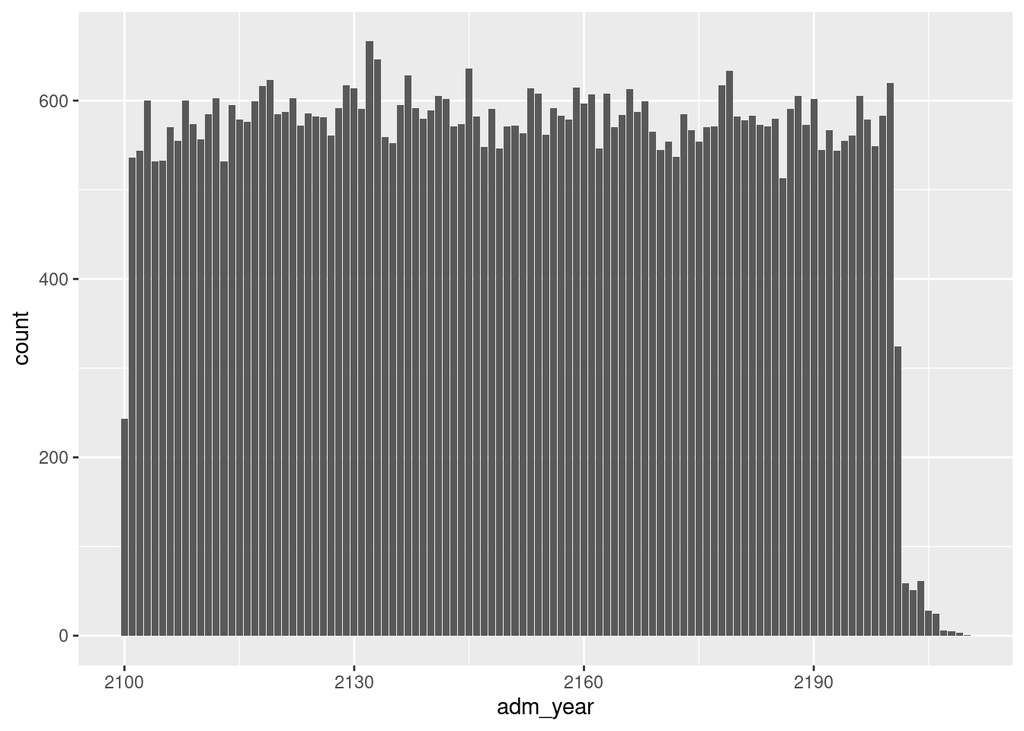

```r
admissions %>%
  mutate(adm_year = year(ADMITTIME)) %>%
  ggplot() +
  geom_bar(mapping = aes(x = adm_year))
```

#Admission month bar graph

**Solution:** The bar graph seems pretty consistent over each month. The average amount of admission per month is about 5000.

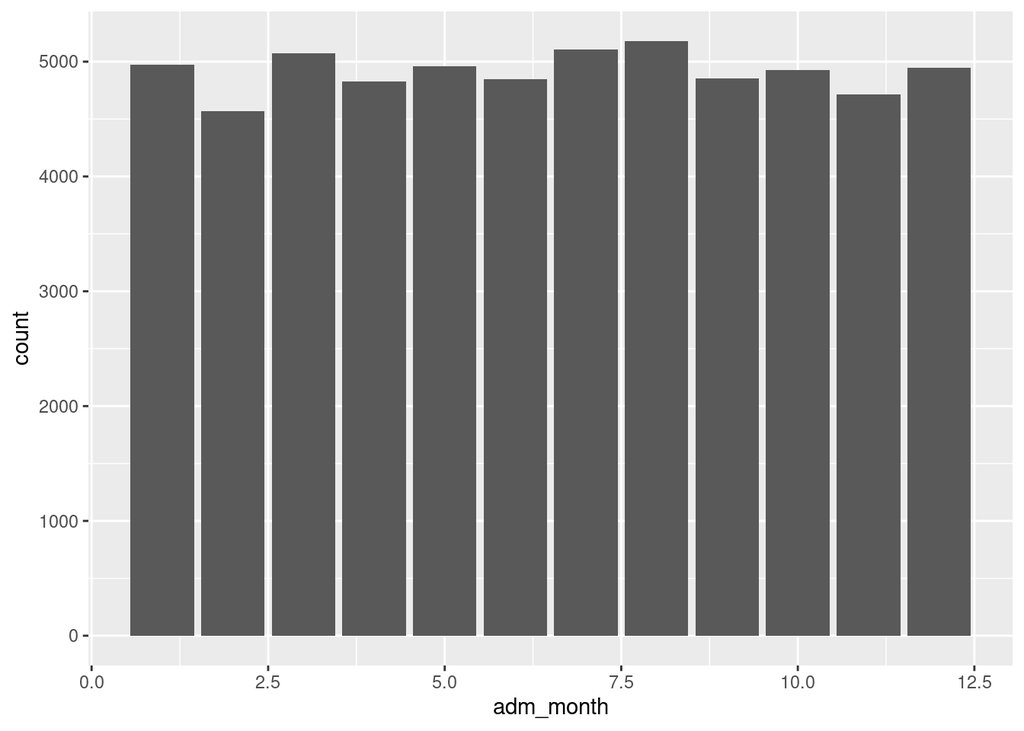

```r
admissions %>%
  mutate(adm_month = month(ADMITTIME)) %>%
  ggplot() +
  geom_bar(mapping = aes(x = adm_month))
```

#Admission week day

**Solution:** According to the days of the week, the weekends in the first and last position are much less compared to the week days. Possibly, it could be related to work injuries or the amount of sheer activities that are done on the week days that allow for the admissions to increase during the week days.

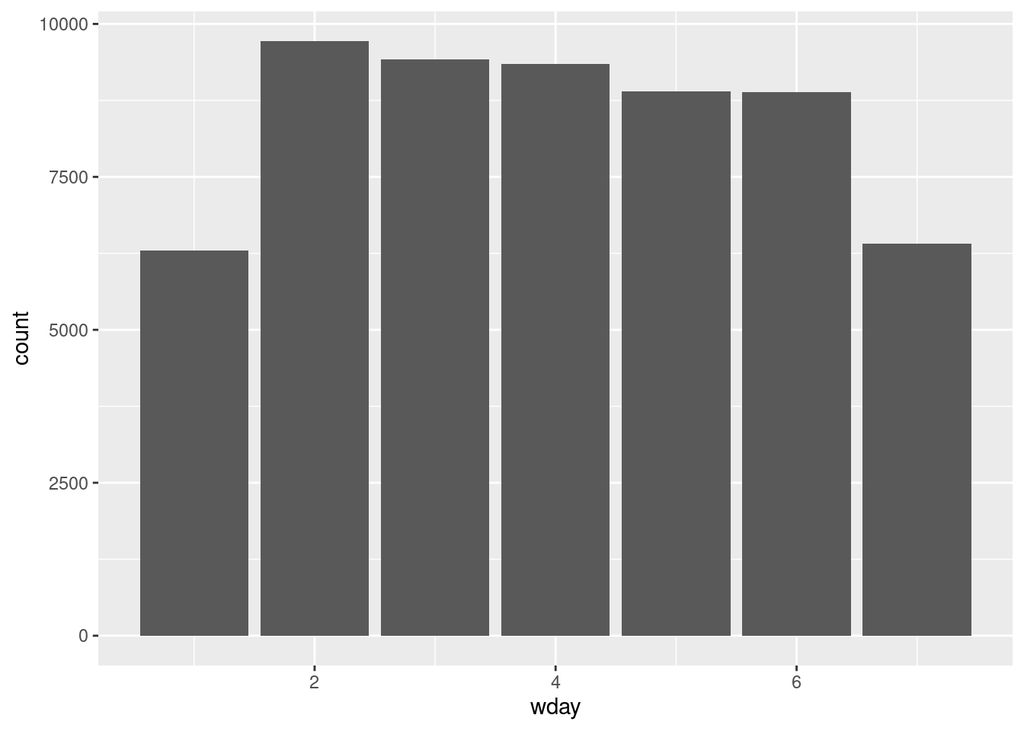

```r
admissions %>%
  mutate(wday = wday(ADMITTIME)) %>%
  ggplot() +
  geom_bar(mapping = aes(x = wday))
```

#Admission hour

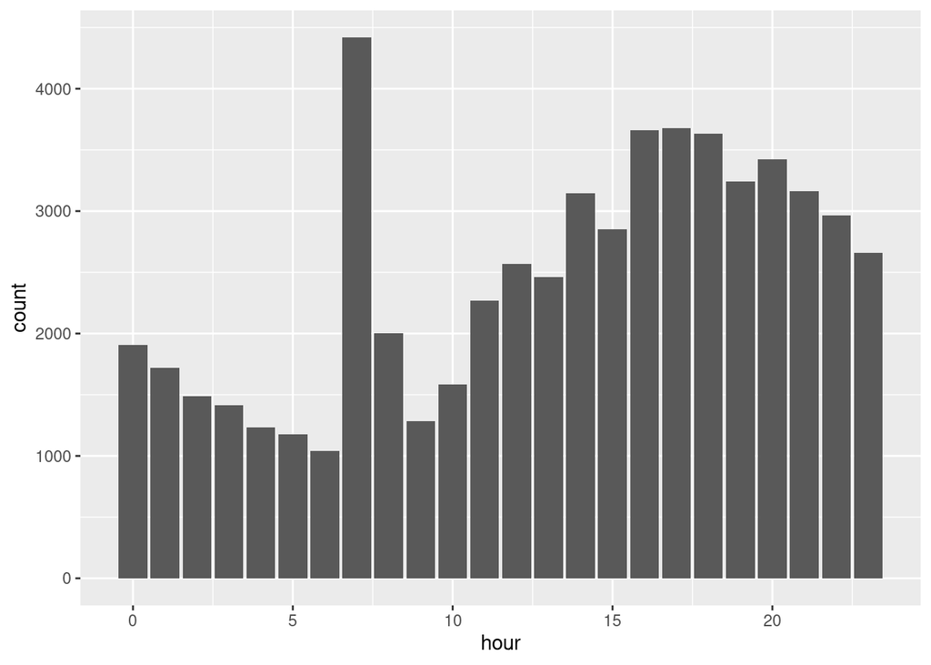

```r
admissions %>%
  mutate(hour = hour(ADMITTIME)) %>%
  ggplot() +
  geom_bar(mapping = aes(x = hour))
```

#Length of stay

**Solution:** The length of stay is skewed right, which means that the length of stay do not normally last more than 100 days; there are very few that are about 100 days, but very miniscule. The max peak seems to be around 3-5 days.

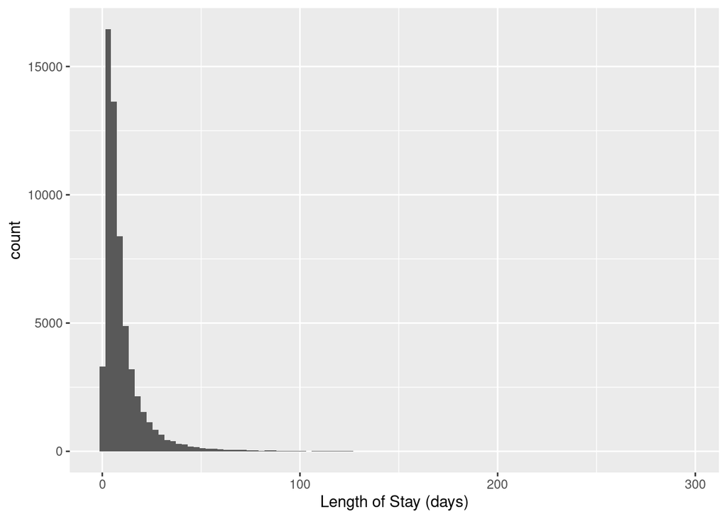

```r
admissions %>%
  mutate(los_days = as.numeric(as.duration(DISCHTIME - ADMITTIME) / 86400)) %>%
  ggplot(aes(x = los_days)) +
  geom_histogram (bins = 100) +
  labs(x = "Length of Stay (days)")
```

#Admission Type

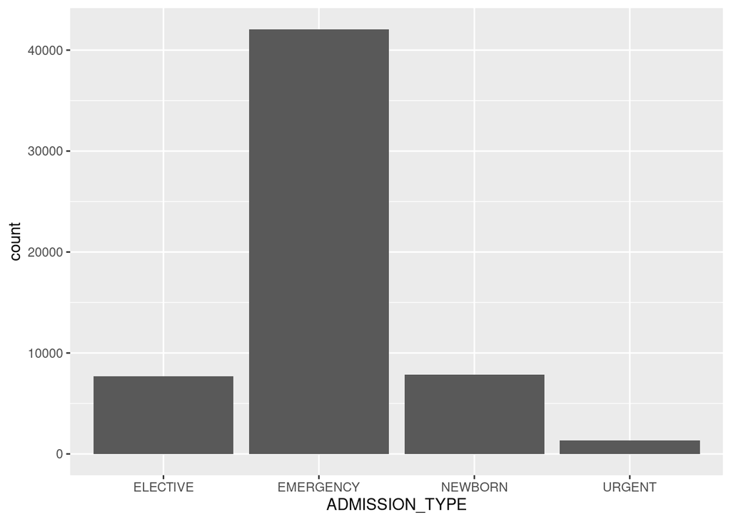

```r
admissions %>%
  group_by(ADMISSION_TYPE) %>%
  summarize(count = n()) %>%
  ggplot(aes(x = ADMISSION_TYPE, y = count)) +
  geom_col()
```

```r
#%>%
 # mutate(freq = N / sum(N),
  #pct = round((freq*100), 0))
```

#Number of Admissions/Patient

**Solution:** On average, there are about one to two admissions per patient. There are a few that have major peaks that may have 6-7 admissions.

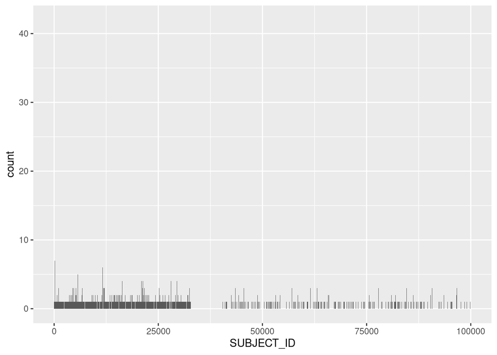

```r
admissions %>%
  group_by(SUBJECT_ID) %>%
  summarize(count = n()) %>%
  ggplot() +
  geom_col(aes(x = SUBJECT_ID, y = count))
```

#Admission Location

**Solution:** The highest admission location is the emergency room admit, which is coherent with the admission type. The other types of admission locations usually deal with the transferring from different hospital or referred from elsewhere.

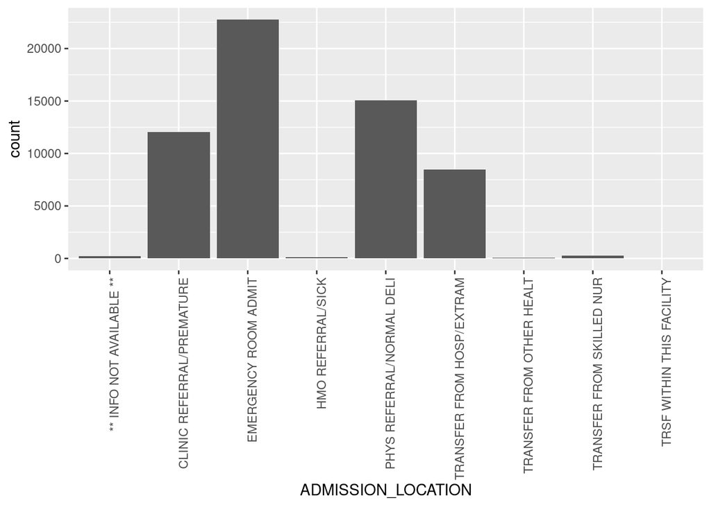

```r
admissions %>%
  group_by(ADMISSION_LOCATION) %>%
  summarize(count = n()) %>%
  ggplot(aes(x = ADMISSION_LOCATION, y = count)) +
  geom_col() +
  theme(axis.text.x = element_text(angle=90, hjust=1))
```

#Insurance sorted by unique values using distinct

**Solution:** The majority of the insurance coverage of the patients come from Medicare, with private being a close second. Very little of the coverage comes from self pay, government, and Medicaid.

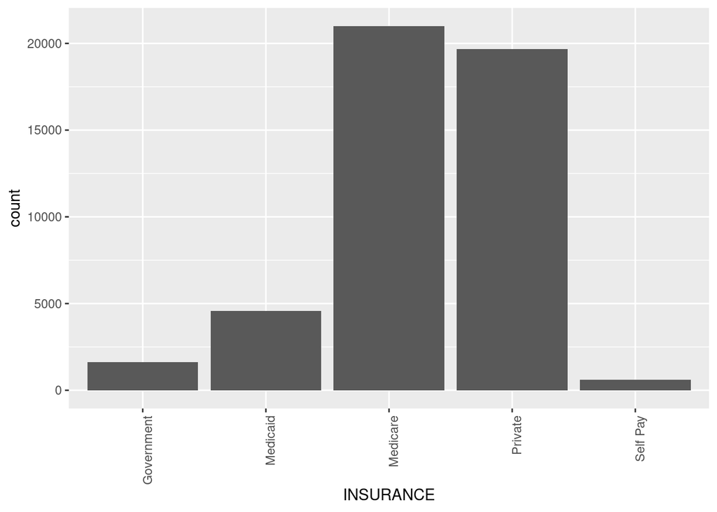

```r
admissions %>%
  group_by(INSURANCE) %>%
  distinct(SUBJECT_ID) %>%
  summarize(count = n()) %>%
  ggplot(aes(x = INSURANCE, y = count)) +
  geom_col() +
  theme(axis.text.x = element_text(angle=90, hjust=1))
```

#Insurance without unique values

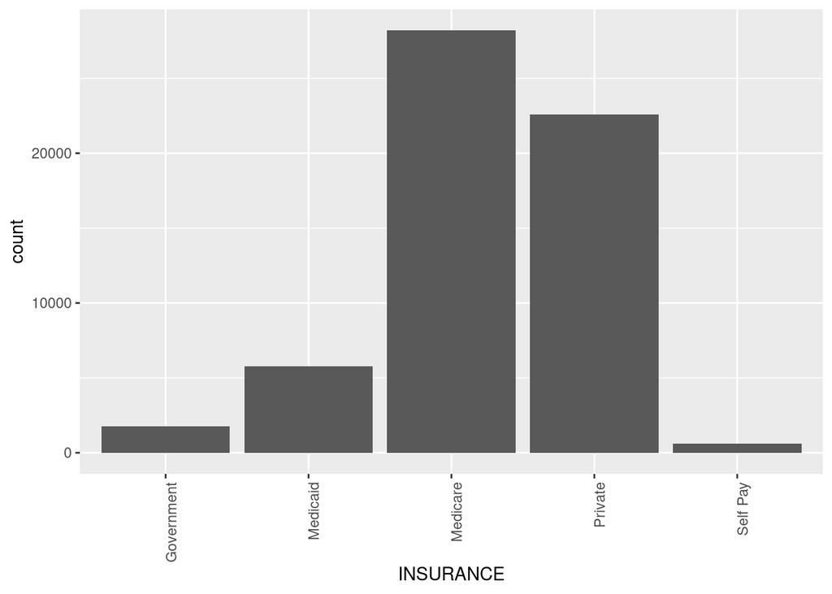

```r
admissions %>%
  group_by(INSURANCE) %>%
  summarize(count = n()) %>%
  ggplot(aes(x = INSURANCE, y = count)) +
  geom_col() +
  theme(axis.text.x = element_text(angle=90, hjust=1))
```

#Language

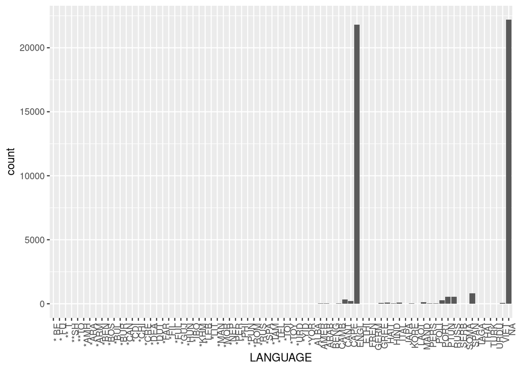

```r
admissions %>%
  group_by(LANGUAGE) %>%
  distinct(SUBJECT_ID) %>%
  summarize(count = n()) %>%
  ggplot(aes(x = LANGUAGE, y = count)) +
  geom_col() +
  theme(axis.text.x = element_text(angle = 90, hjust = 1))
```

#Religion

**Solution:** The majority of the patients admitted are Catholic, I am a little surprised that Chrisitianity is not a specific option, even though there are options that are branched out from Christianity. This could be a reason patients might choose Catholic, since it is similar in some ways. The other major counts are not specified or unobtainable.

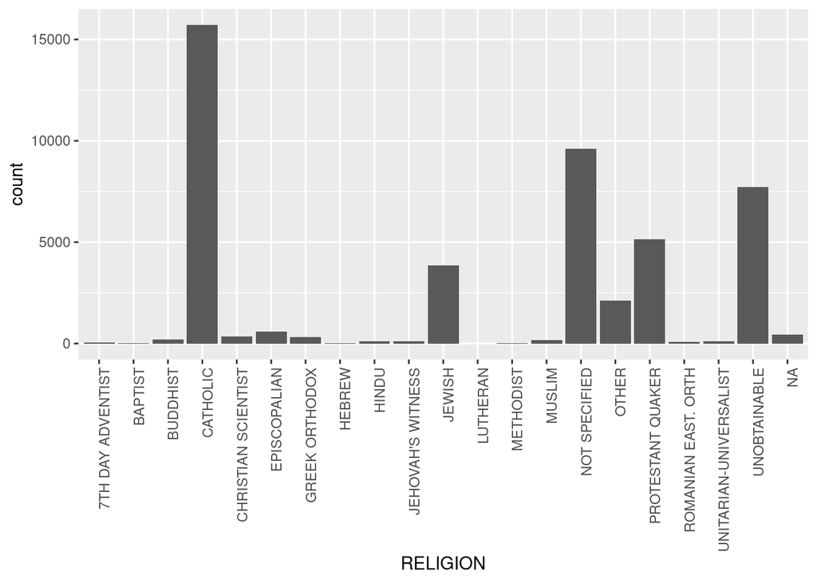

```r
admissions %>%
  group_by(RELIGION) %>%
  distinct(SUBJECT_ID) %>%
  summarize(count = n()) %>%
  ggplot(aes(x = RELIGION, y = count)) +
  geom_col() +
  theme(axis.text.x = element_text(angle=90, hjust=1))
```

#Marital Status

**Solution:** Marital status is represented by a bar graph. The majority of the admitted patients are married, the second major category are single and not available. It is interesting that there were no counts for life partner.

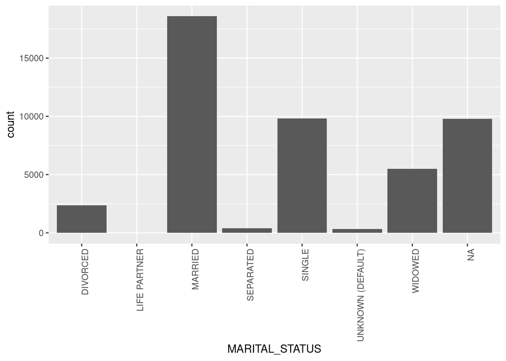

```r
admissions %>%
  group_by(MARITAL_STATUS) %>%
  distinct(SUBJECT_ID) %>%
  summarize(count = n()) %>%
  ggplot(aes(x = MARITAL_STATUS, y = count)) +
  geom_col() +
  theme(axis.text.x = element_text(angle=90, hjust=1))
```

#Ethnicity

**Solution:** The majority of the admitted patients are white, which is roughly 30,000. The second ethnicity to be admitted are African American and those that are unknown, about 5,000.

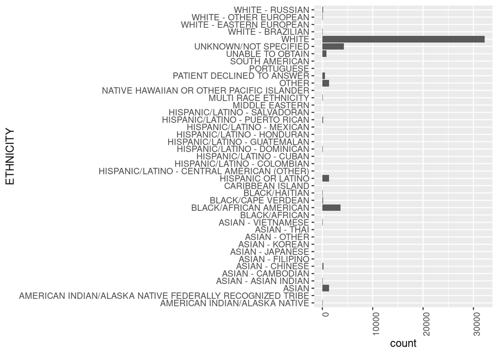

```r
admissions %>%
  group_by(ETHNICITY) %>%
  distinct(SUBJECT_ID) %>%
  summarize(count = n()) %>%
  ggplot(aes(x = ETHNICITY, y = count)) +
  geom_col() +
  theme(axis.text.x = element_text(angle=90, hjust=1)) +
  coord_flip()
```

#Death

**Solution:** Each year, there are about 100-150 deaths. Due to the data’s year span, it should be ten times that amount, thus about 1,000-1,500 deaths/year.

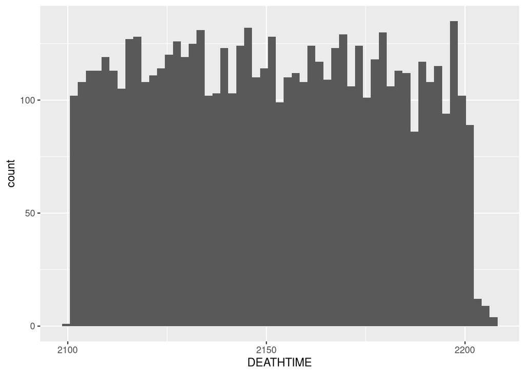

```r
admissions %>%
  group_by(DEATHTIME) %>%
  summarize(count = n()) %>%
  ggplot(aes(x = DEATHTIME)) +
  geom_histogram(bins = 55)
```

## Q2

Link the data in `ADMISSION.csv` and `PATIENTS.csv` (https://mimic.physionet.org/mimictables/patients/) and summarize following variables using appropriate graphs:

- gender
- age at admission

```r
patients <- read_csv("/home/203bdata/mimic-iii/PATIENTS.csv")
patients
```

```
## # A tibble: 46,520 x 8
##    ROW_ID SUBJECT_ID GENDER DOB                 DOD
##     <dbl>      <dbl> <chr>  <dttm>              <dttm>
##  1    234        249 F      2075-03-13 00:00:00 NA
##  2    235        250 F      2164-12-27 00:00:00 2188-11-22 00:00:00
##  3    236        251 M      2090-03-15 00:00:00 NA
##  4    237        252 M      2078-03-06 00:00:00 NA
##  5    238        253 F      2089-11-26 00:00:00 NA
##  6    239        255 M      2109-08-05 00:00:00 NA
##  7    240        256 M      2086-07-31 00:00:00 NA
##  8    241        257 F      2031-04-03 00:00:00 2121-07-08 00:00:00
##  9    242        258 F      2124-09-19 00:00:00 NA
## 10    243        260 F      2105-03-23 00:00:00 NA
## # … with 46,510 more rows, and 3 more variables: DOD_HOSP <dttm>,
## #   DOD_SSN <dttm>, EXPIRE_FLAG <dbl>
```

#Extracted unique subject_id column from admissions

```r
admissions2 <- admissions %>%
  select(SUBJECT_ID) %>%
  distinct(SUBJECT_ID)
  admissions2
```

```
## # A tibble: 46,520 x 1
##    SUBJECT_ID
##         <dbl>
##  1         22
##  2         23
##  3         24
##  4         25
##  5         26
##  6         27
##  7         28
##  8         30
##  9         31
## 10         32
## # … with 46,510 more rows
```

#Extracted subject_id and gender from patients to merge together

```r
patients2 <- patients %>%
  select (SUBJECT_ID, GENDER) %>%
  distinct(SUBJECT_ID, GENDER)
  patients2
```

```
## # A tibble: 46,520 x 2
##    SUBJECT_ID GENDER
##         <dbl> <chr>
##  1        249 F
##  2        250 F
##  3        251 M
##  4        252 M
##  5        253 F
##  6        255 M
##  7        256 M
##  8        257 F
##  9        258 F
## 10        260 F
## # … with 46,510 more rows
```

#Merged the subject_id’s together to determine their gender **Solution:** There are more male admission patients compared to females. There are about 25,000 male patients, whereas females are about 21,000.

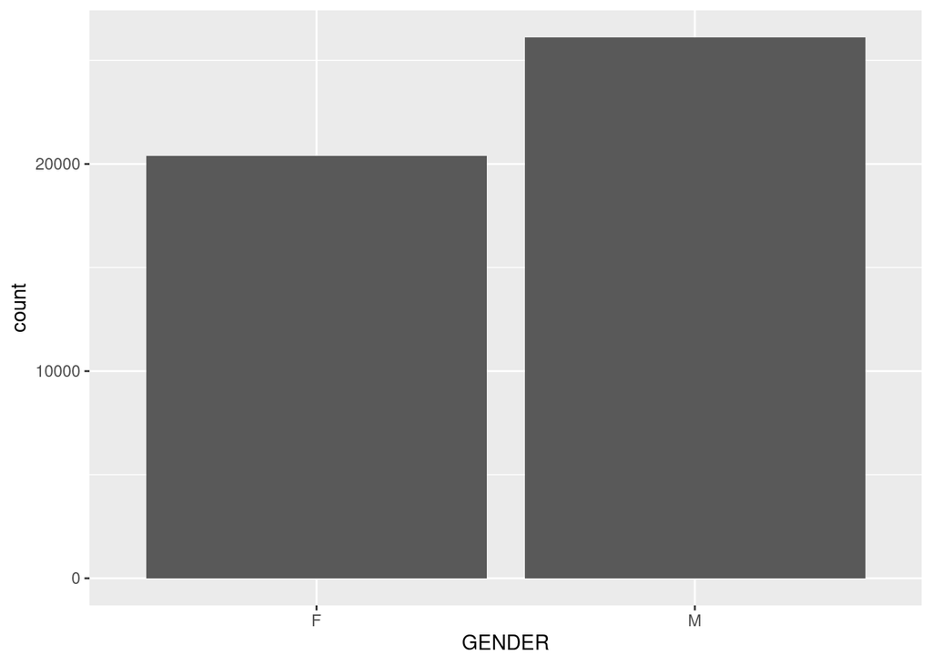

```r
left_join(admissions2, patients2) %>%
group_by(GENDER) %>%
  summarize(count = n()) %>%
  ggplot() +
  geom_col(mapping = aes(x = GENDER, y = count))
```

#Extracted subject_id and admission time, also need to extract year

```r
admissions3 <- admissions %>%
  select (SUBJECT_ID, ADMITTIME) %>%
  mutate(adm_year = year(ADMITTIME)) %>%
  select(SUBJECT_ID, adm_year)
  admissions3
```

```
## # A tibble: 58,976 x 2
##    SUBJECT_ID adm_year
##         <dbl>    <dbl>
##  1         22     2196
##  2         23     2153
##  3         23     2157
##  4         24     2139
##  5         25     2160
##  6         26     2126
##  7         27     2191
##  8         28     2177
##  9         30     2172
## 10         31     2108
## # … with 58,966 more rows
```

#Extracted subject_id and date of birth, need to extract year

```r
patients3 <- patients %>%
  select (SUBJECT_ID, DOB) %>%
  mutate(yearofbirth = year(DOB)) %>%
  select (SUBJECT_ID, yearofbirth)
  patients3
```

```
## # A tibble: 46,520 x 2
##    SUBJECT_ID yearofbirth
##         <dbl>       <dbl>
##  1        249        2075
##  2        250        2164
##  3        251        2090
##  4        252        2078
##  5        253        2089
##  6        255        2109
##  7        256        2086
##  8        257        2031
##  9        258        2124
## 10        260        2105
## # … with 46,510 more rows
```

#Joined subject id, year of birth, and year of admission together and created a new column

```r
joinage <- full_join(admissions3, patients3) %>%
  mutate(age_adm = as.numeric(as.duration(adm_year - yearofbirth)))
  joinage
```

```
## # A tibble: 58,976 x 4
##    SUBJECT_ID adm_year yearofbirth age_adm
##         <dbl>    <dbl>       <dbl>   <dbl>
##  1         22     2196        2131      65
##  2         23     2153        2082      71
##  3         23     2157        2082      75
##  4         24     2139        2100      39
##  5         25     2160        2101      59
##  6         26     2126        2054      72
##  7         27     2191        2191       0
##  8         28     2177        2103      74
##  9         30     2172        1872     300
## 10         31     2108        2036      72
## # … with 58,966 more rows
```

#Created a graph based on the age admissions **Solution:** The data seems a little odd as there are many patients that are above 300, but there are about 8,000 patients that are 0 years which could be dealing with newborns. On average, there are about 1,000 patients that are about 60 to 90 over the span of the data.

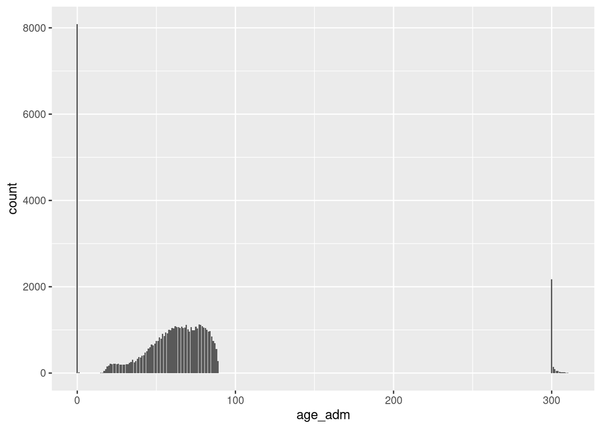

```r
joinage %>%
  group_by(age_adm) %>%
  summarize(count = n()) %>%
  ggplot(aes(x = age_adm, y = count)) +
  geom_col()
```

## Q3

`ICUSTAYS.csv` (https://mimic.physionet.org/mimictables/icustays/) contains data about Intensive Care Units (ICU) stays. Summarize following variables using appropriate graphs:

- length of ICU stay
- first ICU unit
- gender
- age

#Load ICUSTAYS file

```r
icustays <- read_csv("/home/203bdata/mimic-iii/ICUSTAYS.csv")
icustays
```

```
## # A tibble: 61,532 x 12
##    ROW_ID SUBJECT_ID HADM_ID ICUSTAY_ID DBSOURCE FIRST_CAREUNIT LAST_CAREUNIT
##     <dbl>      <dbl>   <dbl>      <dbl> <chr>    <chr>          <chr>
##  1    365        268  110404     280836 carevue  MICU           MICU
##  2    366        269  106296     206613 carevue  MICU           MICU
##  3    367        270  188028     220345 carevue  CCU            CCU
##  4    368        271  173727     249196 carevue  MICU           SICU
##  5    369        272  164716     210407 carevue  CCU            CCU
##  6    370        273  158689     241507 carevue  MICU           MICU
##  7    371        274  130546     254851 carevue  MICU           MICU
##  8    372        275  129886     219649 carevue  CCU            CCU
##  9    373        276  135156     206327 carevue  CCU            CCU
## 10    374        277  171601     272866 carevue  NICU           NICU
## # … with 61,522 more rows, and 5 more variables: FIRST_WARDID <dbl>,
## #   LAST_WARDID <dbl>, INTIME <dttm>, OUTTIME <dttm>, LOS <dbl>
```

#Length of ICUSTAYS

```r
icuduration <- icustays %>%
  select(INTIME, OUTTIME) %>%
  mutate(icu_lengthofstay = as.numeric(as.duration(OUTTIME - INTIME) / 86400))
  icuduration
```

```
## # A tibble: 61,532 x 3
##    INTIME              OUTTIME             icu_lengthofstay
##    <dttm>              <dttm>                         <dbl>
##  1 2198-02-14 23:27:38 2198-02-18 05:26:11            3.25
##  2 2170-11-05 11:05:29 2170-11-08 17:46:57            3.28
##  3 2128-06-24 15:05:20 2128-06-27 12:32:29            2.89
##  4 2120-08-07 23:12:42 2120-08-10 00:39:04            2.06
##  5 2186-12-25 21:08:04 2186-12-27 12:01:13            1.62
##  6 2141-04-19 06:12:05 2141-04-20 17:52:11            1.49
##  7 2114-06-28 22:28:44 2114-07-07 18:01:16            8.81
##  8 2170-10-07 11:28:53 2170-10-14 14:38:07            7.13
##  9 2147-11-20 09:02:23 2147-11-21 17:08:52            1.34
## 10 2132-10-21 21:11:46 2132-10-22 14:44:48            0.731
## # … with 61,522 more rows
```

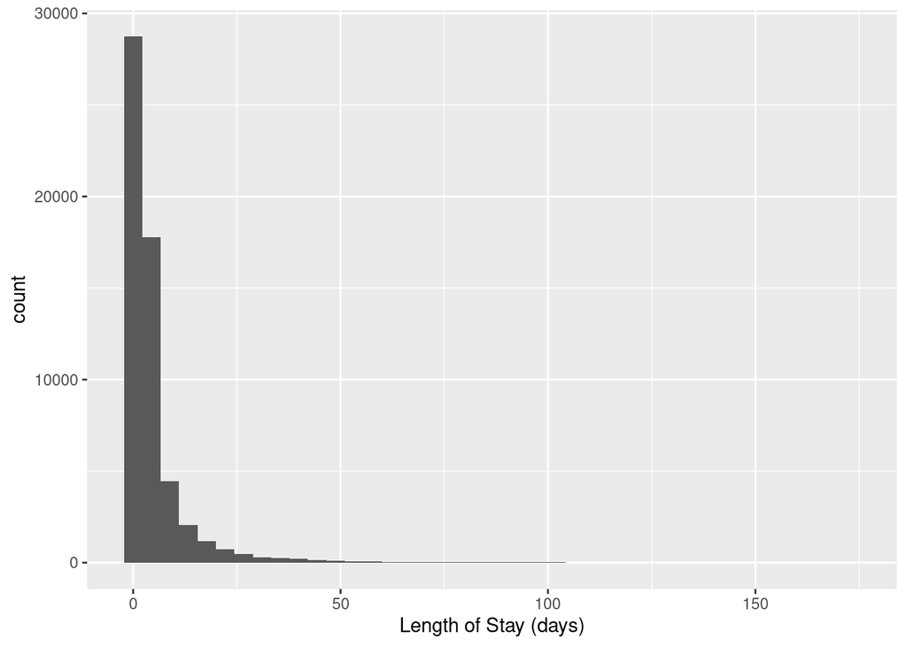

```r
icuduration %>%
  group_by(icu_lengthofstay) %>%
  summarize(count = n()) %>%
  ggplot(aes(x = icu_lengthofstay)) +
  geom_histogram (bins = 40) +
  labs(x = "Length of Stay (days)")
```

#First ICU unit **Solution:** From the bar graph, MICU tends to be the highest count for the first care unit with a count of about 22,000 patients. All the other ICU units, such as CCU, NICU, SICU, and TSICU are averaging about 7,000 patients.

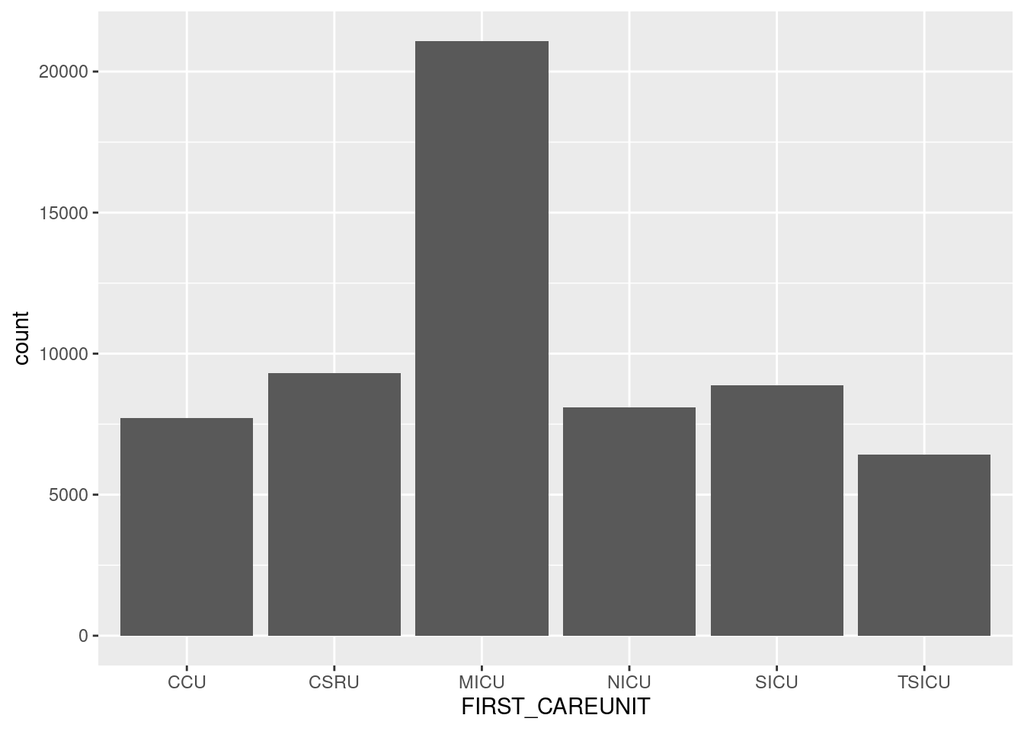

```r
icustays %>%
  group_by(FIRST_CAREUNIT) %>%
  summarize(count = n()) %>%
  ggplot(aes(x = FIRST_CAREUNIT, y = count)) +
  geom_col()
```

#Obtaining unique patients from the ICU unit

```r
icustays2 <- icustays %>%
  select(SUBJECT_ID) %>%
  distinct(SUBJECT_ID)
  icustays2
```

```
## # A tibble: 46,476 x 1
##    SUBJECT_ID
##         <dbl>
##  1        268
##  2        269
##  3        270
##  4        271
##  5        272
##  6        273
##  7        274
##  8        275
##  9        276
## 10        277
## # … with 46,466 more rows
```

#Joining distinct subjects to gender

```r
joinicustay <- left_join(icustays2, patients2)
joinicustay
```

```
## # A tibble: 46,476 x 2
##    SUBJECT_ID GENDER
##         <dbl> <chr>
##  1        268 F
##  2        269 M
##  3        270 M
##  4        271 F
##  5        272 M
##  6        273 M
##  7        274 M
##  8        275 M
##  9        276 M
## 10        277 M
## # … with 46,466 more rows
```

#Graph gender based on ICUSTAYS

**Solution:** This graph actually looks fairly similar to the previous one that was the gender of the admitted patients. The distinct numbers are fairly close to one another, also. In the graph, there are more males admitted to the ICU compared to females.

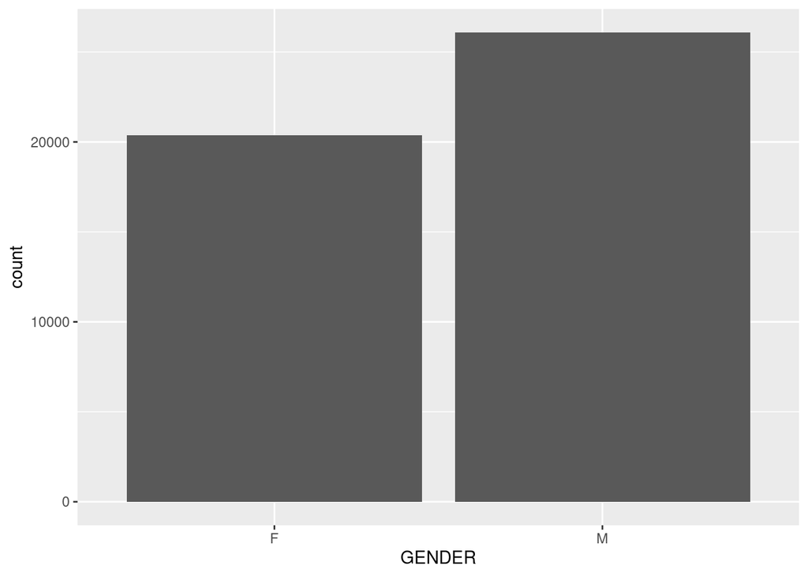

```r
joinicustay %>%
  group_by(GENDER) %>%
  summarize(count = n()) %>%
  ggplot(aes(x = GENDER, y = count)) +
  geom_col()
```

#Tried a different method to see if there was a difference between also adding the admissions and there was no difference. #`{r} joinicustay2 <- left_join (joinicustay, admissions2) joinicustay2` #`{r} joinicustay2 %>% group_by(GENDER) %>% summarize(count = n()) %>% ggplot(aes(x = GENDER, y = count)) + geom_col()`

#Age of ICU patients

```r
icu_ageofadm <- read_csv("/home/203bdata/mimic-iii/ICUSTAYS.csv") %>%
  select(SUBJECT_ID, INTIME)
  icu_ageofadm
```

```
## # A tibble: 61,532 x 2
##    SUBJECT_ID INTIME
##         <dbl> <dttm>
##  1        268 2198-02-14 23:27:38
##  2        269 2170-11-05 11:05:29
##  3        270 2128-06-24 15:05:20
##  4        271 2120-08-07 23:12:42
##  5        272 2186-12-25 21:08:04
##  6        273 2141-04-19 06:12:05
##  7        274 2114-06-28 22:28:44
##  8        275 2170-10-07 11:28:53
##  9        276 2147-11-20 09:02:23
## 10        277 2132-10-21 21:11:46
## # … with 61,522 more rows
```

```r
joined_icu_age <- inner_join(icu_ageofadm, patients3, by = "SUBJECT_ID") %>%
  mutate(icuadm_year = year(INTIME)) %>%
  mutate(icu_aoa = as.numeric(as.duration(icuadm_year - yearofbirth)))
joined_icu_age
```

```
## # A tibble: 61,532 x 5
##    SUBJECT_ID INTIME              yearofbirth icuadm_year icu_aoa
##         <dbl> <dttm>                    <dbl>       <dbl>   <dbl>
##  1        268 2198-02-14 23:27:38        2132        2198      66
##  2        269 2170-11-05 11:05:29        2130        2170      40
##  3        270 2128-06-24 15:05:20        2048        2128      80
##  4        271 2120-08-07 23:12:42        2074        2120      46
##  5        272 2186-12-25 21:08:04        2119        2186      67
##  6        273 2141-04-19 06:12:05        2107        2141      34
##  7        274 2114-06-28 22:28:44        2048        2114      66
##  8        275 2170-10-07 11:28:53        2088        2170      82
##  9        276 2147-11-20 09:02:23        2112        2147      35
## 10        277 2132-10-21 21:11:46        2132        2132       0
## # … with 61,522 more rows
```

#Graph for icu age of admission **Solution:** Similar to the graph in question2, the majority of the ICU age of admissions are around 60-80 years old.There are many counts for 0 and some over the age of 300. This could be the range of the ages in the data that were altered for confidentiality.

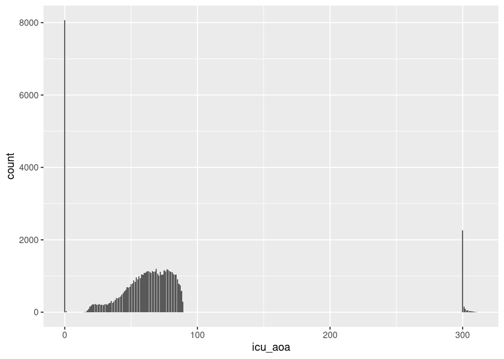

```r
joined_icu_age %>%
  group_by(icu_aoa) %>%
  summarize(count = n()) %>%
  ggplot(aes(x = icu_aoa, y = count)) +
  geom_col()
```

## Q4

`CHARTEVENTS.csv` (https://mimic.physionet.org/mimictables/chartevents/) contains all the charted data available for a patient. During their ICU stay, the primary repository of a patient’s information is their electronic chart. The `ITEMID` variable indicates a single measurement type in the database. The `VALUE` variable is the value measured for `ITEMID`.

`D_ITEMS.csv` (https://mimic.physionet.org/mimictables/d_items/) is the dictionary for the `ITEMID` in `CHARTEVENTS.csv`. Find potential values of `ITEMID` that correspond to systolic blood pressure, i.e., `LABEL` contains the string `systolic`.

```r
library(htmlwidgets)
library(stringr)
```

#Extracted itemid and labels that pertains to the measurement method of itemid

```r
d_items <- read_csv("/home/203bdata/mimic-iii/D_ITEMS.csv") %>%
  select(ITEMID, LABEL)
  d_items
```

```
## # A tibble: 12,487 x 2
##    ITEMID LABEL
##     <dbl> <chr>
##  1    497 Patient controlled analgesia (PCA) [Inject]
##  2    498 PCA Lockout (Min)
##  3    499 PCA Medication
##  4    500 PCA Total Dose
##  5    501 PCV Exh Vt (Obser)
##  6    927 Allergy 2
##  7    930 Ext
##  8    935 Allergy 3
##  9    938 blood cultures
## 10    940 trach care
## # … with 12,477 more rows
```

#Searched for systolic string.

#The ITEMID that contains the word systolic are 226850, 226852, 220050, 220059, and 220179.

```r
systolic <- d_items %>%
  filter(grepl("systolic", LABEL))
  systolic
```

```
## # A tibble: 5 x 2
##   ITEMID LABEL
##    <dbl> <chr>
## 1 226850 RV systolic pressure(PA Line)
## 2 226852 PA systolic pressure(PA Line)
## 3 220050 Arterial Blood Pressure systolic
## 4 220059 Pulmonary Artery Pressure systolic
## 5 220179 Non Invasive Blood Pressure systolic
```

Compile a tibble that contains the first ICU stay of unique patients, with the patient’s demographic information, the first systolic blood pressure measurement during ICU stay, and whether the patient died within 30 days of hospital admission.

#Since d_items didn’t have a column for row_id, thus merging d_items to icustays

```r
ditems_row <- read_csv("/home/203bdata/mimic-iii/D_ITEMS.csv") %>%
  select(ITEMID, LABEL)
ditems_row
```

```
## # A tibble: 12,487 x 2
##    ITEMID LABEL
##     <dbl> <chr>
##  1    497 Patient controlled analgesia (PCA) [Inject]
##  2    498 PCA Lockout (Min)
##  3    499 PCA Medication
##  4    500 PCA Total Dose
##  5    501 PCV Exh Vt (Obser)
##  6    927 Allergy 2
##  7    930 Ext
##  8    935 Allergy 3
##  9    938 blood cultures
## 10    940 trach care
## # … with 12,477 more rows
```

```r
icustays_time <- read_csv("/home/203bdata/mimic-iii/ICUSTAYS.csv") %>%
  select(ROW_ID, SUBJECT_ID, INTIME) %>%
  group_by(SUBJECT_ID)
  icustays_time
```

```
## # A tibble: 61,532 x 3
## # Groups:   SUBJECT_ID [46,476]
##    ROW_ID SUBJECT_ID INTIME
##     <dbl>      <dbl> <dttm>
##  1    365        268 2198-02-14 23:27:38
##  2    366        269 2170-11-05 11:05:29
##  3    367        270 2128-06-24 15:05:20
##  4    368        271 2120-08-07 23:12:42
##  5    369        272 2186-12-25 21:08:04
##  6    370        273 2141-04-19 06:12:05
##  7    371        274 2114-06-28 22:28:44
##  8    372        275 2170-10-07 11:28:53
##  9    373        276 2147-11-20 09:02:23
## 10    374        277 2132-10-21 21:11:46
## # … with 61,522 more rows
```

#arranged the subjects and intime by ascending order and was able to extract the distinct subjects with the first time they were in the ICU

```r
ascend_time <- read_csv("/home/203bdata/mimic-iii/ICUSTAYS.csv") %>%
  select(SUBJECT_ID, ICUSTAY_ID, INTIME) %>%
  arrange(SUBJECT_ID, INTIME) %>%
  group_by(SUBJECT_ID) %>%
  distinct(SUBJECT_ID, .keep_all = TRUE)
ascend_time
```

```
## # A tibble: 46,476 x 3
## # Groups:   SUBJECT_ID [46,476]
##    SUBJECT_ID ICUSTAY_ID INTIME
##         <dbl>      <dbl> <dttm>
##  1          2     243653 2138-07-17 21:20:07
##  2          3     211552 2101-10-20 19:10:11
##  3          4     294638 2191-03-16 00:29:31
##  4          5     214757 2103-02-02 06:04:24
##  5          6     228232 2175-05-30 21:30:54
##  6          7     278444 2121-05-23 15:35:29
##  7          8     262299 2117-11-20 12:36:10
##  8          9     220597 2149-11-09 13:07:02
##  9         10     288409 2103-06-28 11:39:05
## 10         11     229441 2178-04-16 06:19:32
## # … with 46,466 more rows
```

#First systolic blood pressure measurement during ICU stay

```r
allinfo <- read_csv("/home/203bdata/mimic-iii/CHARTEVENTS.csv") %>%
  select(SUBJECT_ID, ICUSTAY_ID, ITEMID, VALUE) %>%
  group_by(SUBJECT_ID) %>%
  arrange(SUBJECT_ID) %>%
  distinct(SUBJECT_ID, .keep_all = TRUE) %>%
  select(SUBJECT_ID, ICUSTAY_ID, VALUE, ITEMID)
allinfo
```

```
## # A tibble: 499 x 4
## # Groups:   SUBJECT_ID [499]
##    SUBJECT_ID ICUSTAY_ID VALUE ITEMID
##         <dbl>      <dbl> <dbl>  <dbl>
##  1         23     234044  58   220180
##  2         34     290505  66   220180
##  3         36     241249  15   223834
##  4         85     291697 160   223751
##  5        107     252542  61   220180
##  6        109     241668   8.5 220228
##  7        111     249202   3.2 225668
##  8        124     256064   0   224689
##  9        154     201272  62   220180
## 10        165     247247  97.3 223761
## # … with 489 more rows
```

#Merge chartevents(subj, icustayid, itemid, value) and d_items(itemid, label) to get the itemid to match the label for the subjects and then filtered for systolic measurements

```r
filter_firstsystolic <- inner_join(allinfo, ditems_row, by = "ITEMID") %>%
  filter(grepl("systolic", LABEL)) %>%
  select(SUBJECT_ID, ICUSTAY_ID, ITEMID, LABEL, VALUE)
filter_firstsystolic
```

```
## # A tibble: 41 x 5
## # Groups:   SUBJECT_ID [41]
##    SUBJECT_ID ICUSTAY_ID ITEMID LABEL                                VALUE
##         <dbl>      <dbl>  <dbl> <chr>                                <dbl>
##  1        266     293876 220179 Non Invasive Blood Pressure systolic   132
##  2        291     246725 220179 Non Invasive Blood Pressure systolic   131
##  3        523     227379 220179 Non Invasive Blood Pressure systolic   109
##  4       1197     211766 220179 Non Invasive Blood Pressure systolic   119
##  5       1986     248080 220179 Non Invasive Blood Pressure systolic   100
##  6       2100     202887 220179 Non Invasive Blood Pressure systolic   126
##  7       2338     286713 220179 Non Invasive Blood Pressure systolic    99
##  8       2598     250541 220179 Non Invasive Blood Pressure systolic   123
##  9       2747     208893 220050 Arterial Blood Pressure systolic       107
## 10       3250     207046 220179 Non Invasive Blood Pressure systolic    92
## # … with 31 more rows
```

#demographs of patients in admissions

```r
demo_adm <- admissions %>%
  select(SUBJECT_ID, LANGUAGE, ETHNICITY, MARITAL_STATUS)
  demo_adm
```

```
## # A tibble: 58,976 x 4
##    SUBJECT_ID LANGUAGE ETHNICITY             MARITAL_STATUS
##         <dbl> <chr>    <chr>                 <chr>
##  1         22 <NA>     WHITE                 MARRIED
##  2         23 <NA>     WHITE                 MARRIED
##  3         23 ENGL     WHITE                 MARRIED
##  4         24 <NA>     WHITE                 SINGLE
##  5         25 <NA>     WHITE                 MARRIED
##  6         26 <NA>     UNKNOWN/NOT SPECIFIED SINGLE
##  7         27 <NA>     WHITE                 <NA>
##  8         28 <NA>     WHITE                 MARRIED
##  9         30 <NA>     UNKNOWN/NOT SPECIFIED MARRIED
## 10         31 <NA>     WHITE                 MARRIED
## # … with 58,966 more rows
```

#Merge unique ICU subjects with demographic info, along with systolic measurements and value

```r
systolic_demo <-
  inner_join(filter_firstsystolic, demo_adm, by = "SUBJECT_ID") %>%
  distinct(SUBJECT_ID, .keep_all = TRUE)
  systolic_demo
```

```
## # A tibble: 41 x 8
## # Groups:   SUBJECT_ID [41]
##    SUBJECT_ID ICUSTAY_ID ITEMID LABEL    VALUE LANGUAGE ETHNICITY MARITAL_STATUS
##         <dbl>      <dbl>  <dbl> <chr>    <dbl> <chr>    <chr>     <chr>
##  1        266     293876 220179 Non Inv…   132 ENGL     BLACK/AF… WIDOWED
##  2        291     246725 220179 Non Inv…   131 ENGL     WHITE     SINGLE
##  3        523     227379 220179 Non Inv…   109 ENGL     WHITE     WIDOWED
##  4       1197     211766 220179 Non Inv…   119 ENGL     BLACK/AF… SINGLE
##  5       1986     248080 220179 Non Inv…   100 ENGL     HISPANIC… SINGLE
##  6       2100     202887 220179 Non Inv…   126 <NA>     WHITE     MARRIED
##  7       2338     286713 220179 Non Inv…    99 <NA>     WHITE     MARRIED
##  8       2598     250541 220179 Non Inv…   123 <NA>     WHITE     WIDOWED
##  9       2747     208893 220050 Arteria…   107 <NA>     WHITE     MARRIED
## 10       3250     207046 220179 Non Inv…    92 <NA>     WHITE     MARRIED
## # … with 31 more rows
```

#Extracted patients who have died

```r
patients_dod <- read_csv("/home/203bdata/mimic-iii/PATIENTS.csv") %>%
  select(SUBJECT_ID, DOD) %>%
  group_by(SUBJECT_ID) %>%
  distinct(SUBJECT_ID, DOD, .keep_all = TRUE)
  patients_dod
```

```
## # A tibble: 46,520 x 2
## # Groups:   SUBJECT_ID [46,520]
##    SUBJECT_ID DOD
##         <dbl> <dttm>
##  1        249 NA
##  2        250 2188-11-22 00:00:00
##  3        251 NA
##  4        252 NA
##  5        253 NA
##  6        255 NA
##  7        256 NA
##  8        257 2121-07-08 00:00:00
##  9        258 NA
## 10        260 NA
## # … with 46,510 more rows
```

#Joined date of death to the subject intime to determine if they died within 30 days

```r
dod_intime <- inner_join(ascend_time, patients_dod, by = "SUBJECT_ID") %>%
  mutate(intime_date = date(INTIME)) %>%
  mutate(dateofdeath = date(DOD))
dod_intime
```

```
## # A tibble: 46,476 x 6
## # Groups:   SUBJECT_ID [46,476]
##    SUBJECT_ID ICUSTAY_ID INTIME              DOD                 intime_date
##         <dbl>      <dbl> <dttm>              <dttm>              <date>
##  1          2     243653 2138-07-17 21:20:07 NA                  2138-07-17
##  2          3     211552 2101-10-20 19:10:11 2102-06-14 00:00:00 2101-10-20
##  3          4     294638 2191-03-16 00:29:31 NA                  2191-03-16
##  4          5     214757 2103-02-02 06:04:24 NA                  2103-02-02
##  5          6     228232 2175-05-30 21:30:54 NA                  2175-05-30
##  6          7     278444 2121-05-23 15:35:29 NA                  2121-05-23
##  7          8     262299 2117-11-20 12:36:10 NA                  2117-11-20
##  8          9     220597 2149-11-09 13:07:02 2149-11-14 00:00:00 2149-11-09
##  9         10     288409 2103-06-28 11:39:05 NA                  2103-06-28
## 10         11     229441 2178-04-16 06:19:32 2178-11-14 00:00:00 2178-04-16
## # … with 46,466 more rows, and 1 more variable: dateofdeath <date>
```

#Created a new column for the amount of days that died within 30 days of hospital admission

```r
final_within <- dod_intime %>%
  mutate(within_thirtydays = as.numeric(as.duration(dateofdeath - intime_date) / 86400)) %>%
  drop_na() %>%
  filter(within_thirtydays < 30) %>%
  select(SUBJECT_ID, intime_date, dateofdeath, within_thirtydays)
final_within
```

```
## # A tibble: 5,297 x 4
## # Groups:   SUBJECT_ID [5,297]
##    SUBJECT_ID intime_date dateofdeath within_thirtydays
##         <dbl> <date>      <date>                  <dbl>
##  1          9 2149-11-09  2149-11-14                  5
##  2         12 2104-08-08  2104-08-20                 12
##  3         31 2108-08-22  2108-08-30                  8
##  4         56 2104-01-02  2104-01-08                  6
##  5         81 2192-01-09  2192-01-12                  3
##  6         84 2196-04-16  2196-04-17                  1
##  7         91 2177-04-27  2177-05-10                 13
##  8        101 2196-09-26  2196-10-12                 16
##  9        103 2144-08-12  2144-09-01                 20
## 10        106 2192-08-09  2192-08-15                  6
## # … with 5,287 more rows
```

```r
inner_join(ascend_time, allinfo, by = "SUBJECT_ID")
```

```
## # A tibble: 499 x 6
## # Groups:   SUBJECT_ID [499]
##    SUBJECT_ID ICUSTAY_ID.x INTIME              ICUSTAY_ID.y VALUE ITEMID
##         <dbl>        <dbl> <dttm>                     <dbl> <dbl>  <dbl>
##  1         23       227807 2153-09-03 09:38:55       234044  58   220180
##  2         34       263086 2186-07-18 18:10:49       290505  66   220180
##  3         36       280987 2131-05-04 10:29:14       241249  15   223834
##  4         85       209562 2162-03-03 13:03:47       291697 160   223751
##  5        107       244517 2115-02-20 17:42:27       252542  61   220180
##  6        109       277062 2137-11-04 19:37:58       241668   8.5 220228
##  7        111       254245 2142-04-24 06:56:33       249202   3.2 225668
##  8        124       255660 2160-07-09 19:47:26       256064   0   224689
##  9        154       275949 2117-12-29 21:37:00       201272  62   220180
## 10        165       247247 2170-10-03 17:17:53       247247  97.3 223761
## # … with 489 more rows
```

#joined unique patients and demographics of patients in admissions #`{r} joinu_d <- inner_join(admissions_subj, demo_adm, by = "SUBJECT_ID") joinu_d`

#joined unique patients and first icu units from ICUSTAYS with unique patients & demographics in admissions #`{r} inner_join(joinu_ficu, joinu_d, by = "SUBJECT_ID")`